# Aid Data

Nicole Yamzon and Joseph Malionek

5/22/2019

## R Markdown

When we first looked at the data, (after hours and hours of technical difficulties), we did a plot of all of the donations just to test things and see what the data looked like. After seeing that mess (even the truncated we were using was a quarter of a gigabyte and we had a point in the graph for each row in the set…not pretty), we noticed that as time increased, the total amount of donations seemed constant, but there were a great deal more smaller donations. We also noticed that there was a large chunk of donations from United Nations organizations, and so we wanted to see if those trends matched with the rest of the world. So, we first checked and saw that the total number of donations was increasing:

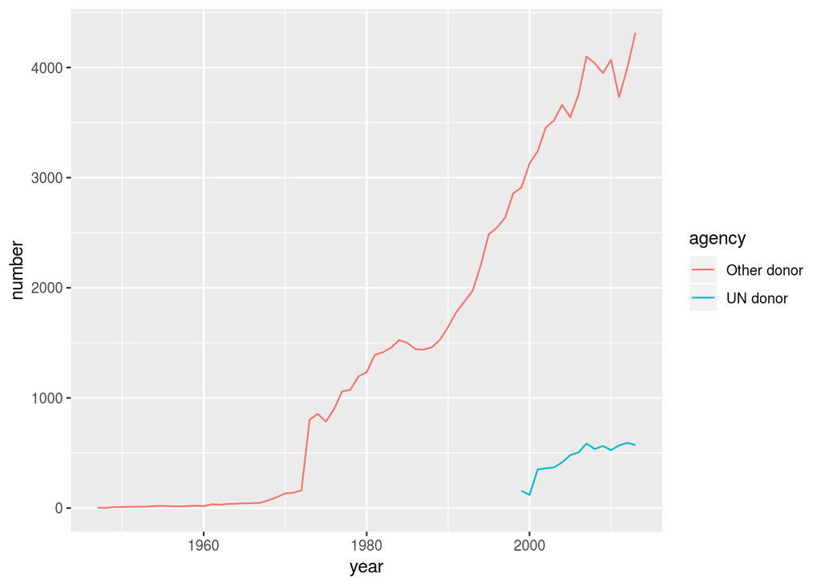

```r
recip_res %>% filter( year < 2020) %>%
  mutate(un = str_detect(donor, "(United Nations)|UN")) %>%
  group_by(un, year) %>%
  summarize(number = n(),
            average = mean(commitment_amount_usd_constant_sum),
            donation_range = max(commitment_amount_usd_constant_sum)-min(commitment_amount_usd_constant_sum)) -> modified_aid
modified_aid$agency = ifelse(modified_aid$un,"UN donor", "Other donor")
ggplot(modified_aid) +
  geom_line(aes(x = year , y = number, color = agency))
```

Then we checked the average donation size

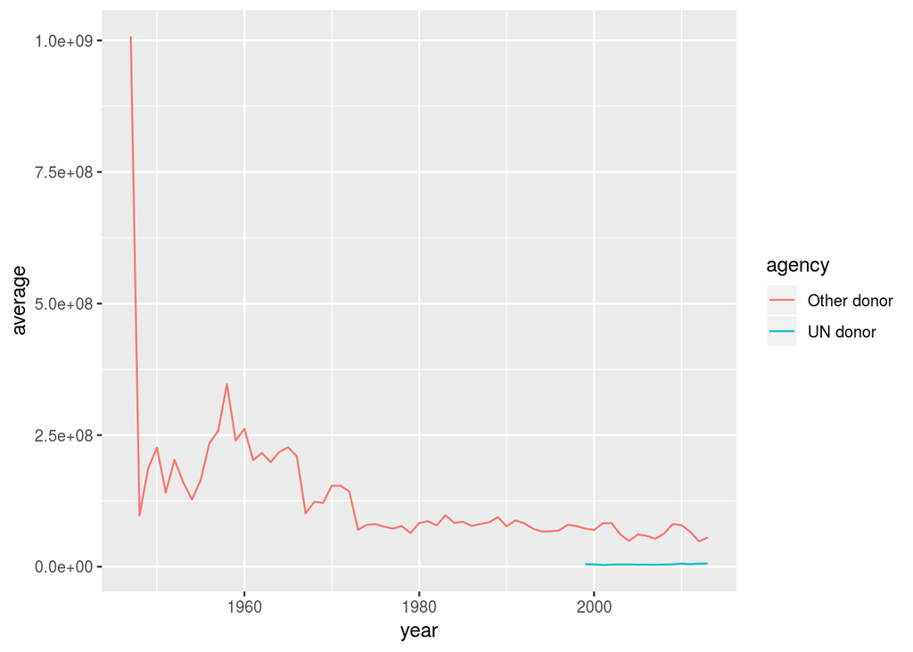

So, for most of the agencies, the average donation size is trending downwards, but not for UN agencies, but in both cases, the number of donations is steadily increasing.